# The anlysis of white wine by lin shou bao

========================================================

```
## [1] 4898   13
```

```
## 'data.frame':    4898 obs. of  13 variables:
##  $ X                   : int  1 2 3 4 5 6 7 8 9 10 ...
##  $ fixed.acidity       : num  7 6.3 8.1 7.2 7.2 8.1 6.2 7 6.3 8.1 ...
##  $ volatile.acidity    : num  0.27 0.3 0.28 0.23 0.23 0.28 0.32 0.27 0.3 0.22 ...
##  $ citric.acid         : num  0.36 0.34 0.4 0.32 0.32 0.4 0.16 0.36 0.34 0.43 ...
##  $ residual.sugar      : num  20.7 1.6 6.9 8.5 8.5 6.9 7 20.7 1.6 1.5 ...
##  $ chlorides           : num  0.045 0.049 0.05 0.058 0.058 0.05 0.045 0.045 0.049 0.044 ...
##  $ free.sulfur.dioxide : num  45 14 30 47 47 30 30 45 14 28 ...
##  $ total.sulfur.dioxide: num  170 132 97 186 186 97 136 170 132 129 ...
##  $ density             : num  1.001 0.994 0.995 0.996 0.996 ...
##  $ pH                  : num  3 3.3 3.26 3.19 3.19 3.26 3.18 3 3.3 3.22 ...
##  $ sulphates           : num  0.45 0.49 0.44 0.4 0.4 0.44 0.47 0.45 0.49 0.45 ...
##  $ alcohol             : num  8.8 9.5 10.1 9.9 9.9 10.1 9.6 8.8 9.5 11 ...
##  $ quality             : int  6 6 6 6 6 6 6 6 6 6 ...
```

```
##        X        fixed.acidity    volatile.acidity  citric.acid
##  Min.   :   1   Min.   : 3.800   Min.   :0.0800   Min.   :0.0000
##  1st Qu.:1225   1st Qu.: 6.300   1st Qu.:0.2100   1st Qu.:0.2700
##  Median :2450   Median : 6.800   Median :0.2600   Median :0.3200
##  Mean   :2450   Mean   : 6.855   Mean   :0.2782   Mean   :0.3342
##  3rd Qu.:3674   3rd Qu.: 7.300   3rd Qu.:0.3200   3rd Qu.:0.3900
##  Max.   :4898   Max.   :14.200   Max.   :1.1000   Max.   :1.6600
##  residual.sugar     chlorides       free.sulfur.dioxide
##  Min.   : 0.600   Min.   :0.00900   Min.   :  2.00
##  1st Qu.: 1.700   1st Qu.:0.03600   1st Qu.: 23.00
##  Median : 5.200   Median :0.04300   Median : 34.00
##  Mean   : 6.391   Mean   :0.04577   Mean   : 35.31
##  3rd Qu.: 9.900   3rd Qu.:0.05000   3rd Qu.: 46.00
##  Max.   :65.800   Max.   :0.34600   Max.   :289.00
##  total.sulfur.dioxide    density             pH          sulphates
##  Min.   :  9.0        Min.   :0.9871   Min.   :2.720   Min.   :0.2200
##  1st Qu.:108.0        1st Qu.:0.9917   1st Qu.:3.090   1st Qu.:0.4100
##  Median :134.0        Median :0.9937   Median :3.180   Median :0.4700
##  Mean   :138.4        Mean   :0.9940   Mean   :3.188   Mean   :0.4898
##  3rd Qu.:167.0        3rd Qu.:0.9961   3rd Qu.:3.280   3rd Qu.:0.5500
##  Max.   :440.0        Max.   :1.0390   Max.   :3.820   Max.   :1.0800
##     alcohol         quality
##  Min.   : 8.00   Min.   :3.000
##  1st Qu.: 9.50   1st Qu.:5.000
##  Median :10.40   Median :6.000
##  Mean   :10.51   Mean   :5.878
##  3rd Qu.:11.40   3rd Qu.:6.000
##  Max.   :14.20   Max.   :9.000
```

在白葡萄酒数据集中，有13个变量，4898个观测值。

# Univariate Plots Section

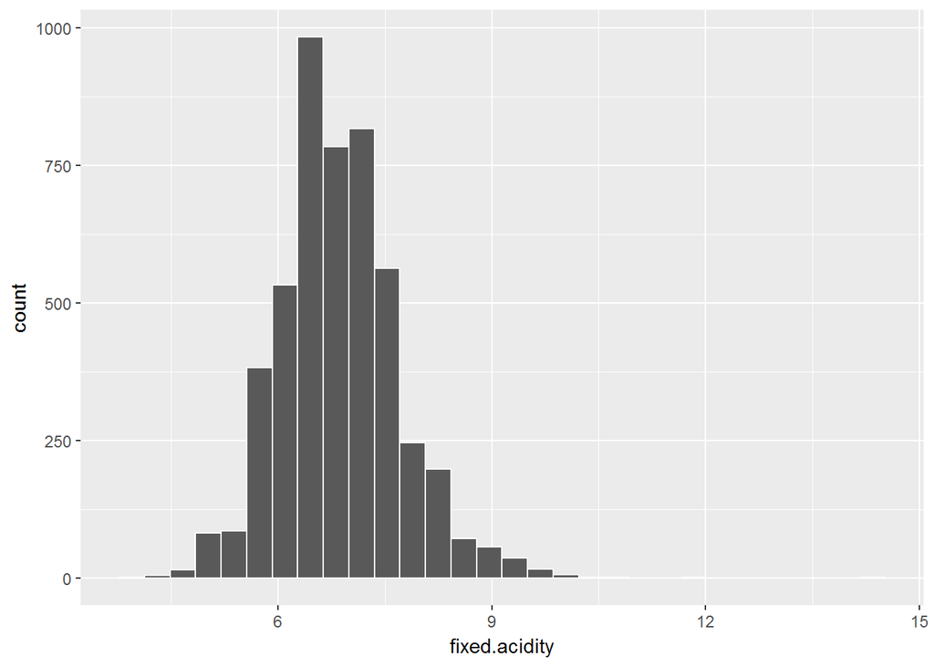

从固定酸度直方图，可以看出白葡萄酒固定酸度大部分集中6-8之间。

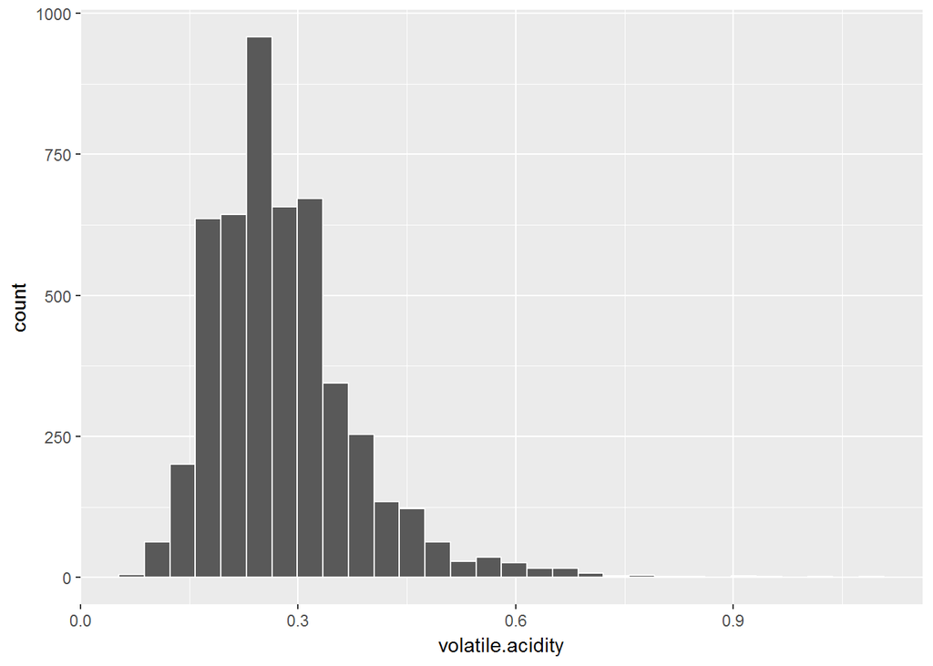

```
##    Min. 1st Qu.  Median    Mean 3rd Qu.    Max.
##  0.0800  0.2100  0.2600  0.2782  0.3200  1.1000
```

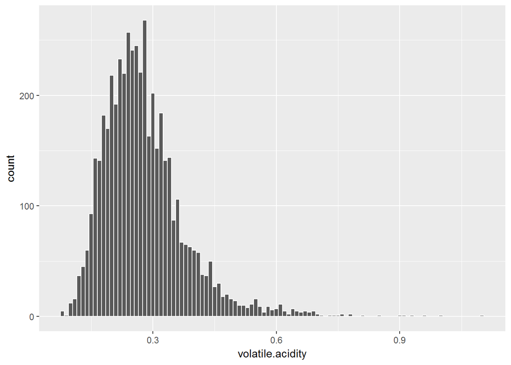

从挥发酸度直方图，可以看出白葡萄酒中挥发酸度大部分保持在0.2-0.4，0.9这里存在异常值，缩小组距后发现存在多个异常值。

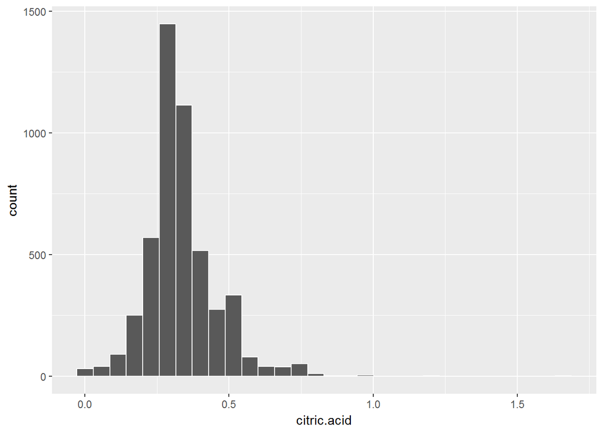

```
##    Min. 1st Qu.  Median    Mean 3rd Qu.    Max.
##  0.0000  0.2700  0.3200  0.3342  0.3900  1.6600
```

柠檬酸主要集中在0.2-0.4之间,通过总结看出最大值1.66远超上四分位数0.39，存在异常值。

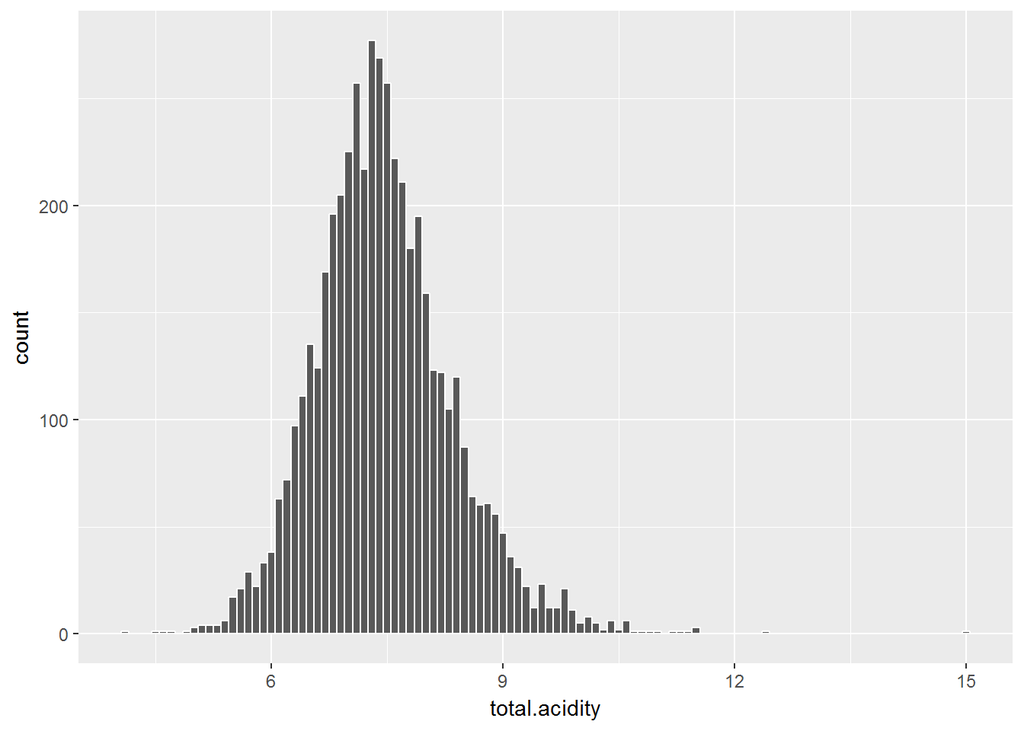

```
##    Min. 1st Qu.  Median    Mean 3rd Qu.    Max.
##   4.130   6.890   7.405   7.467   7.960  14.960
```

大部分白葡萄酒总酸度集中在6-9。

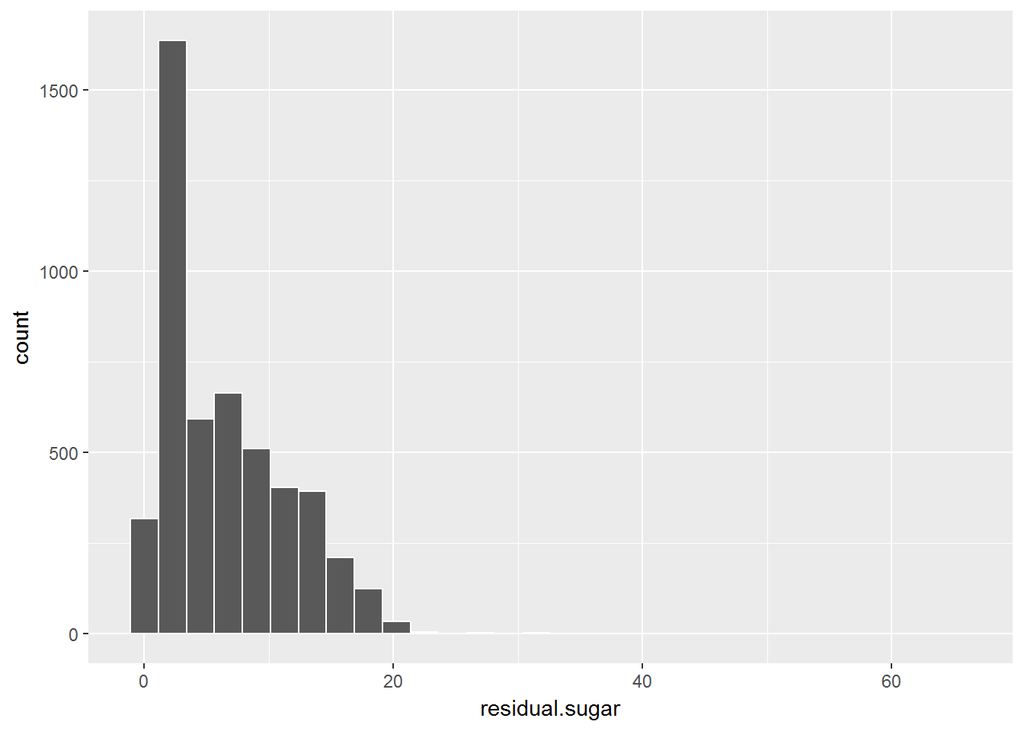

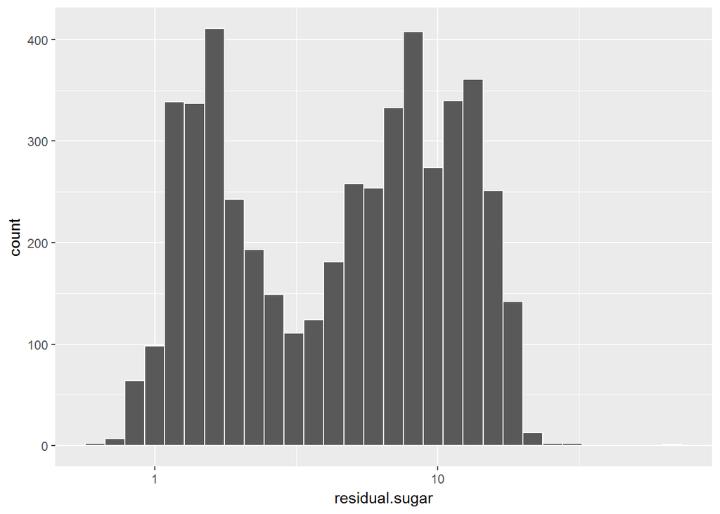

```
##    Min. 1st Qu.  Median    Mean 3rd Qu.    Max.
##   0.600   1.700   5.200   6.391   9.900  65.800
```

残糖维持在0-20之间，最大值为65.8，因此存在异常值。残糖取对数后，出现了双峰分布，说明残糖含量大部分集中在两个部分。

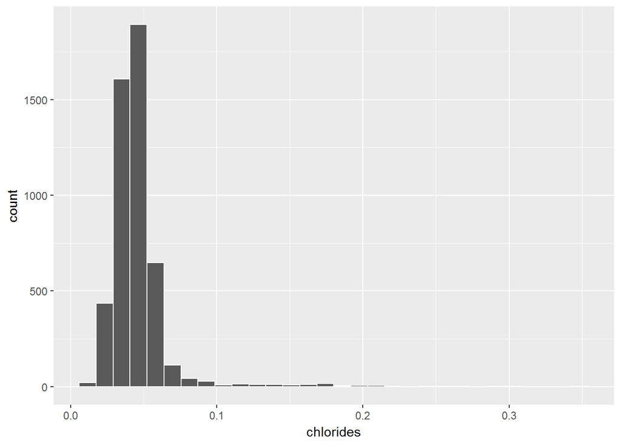

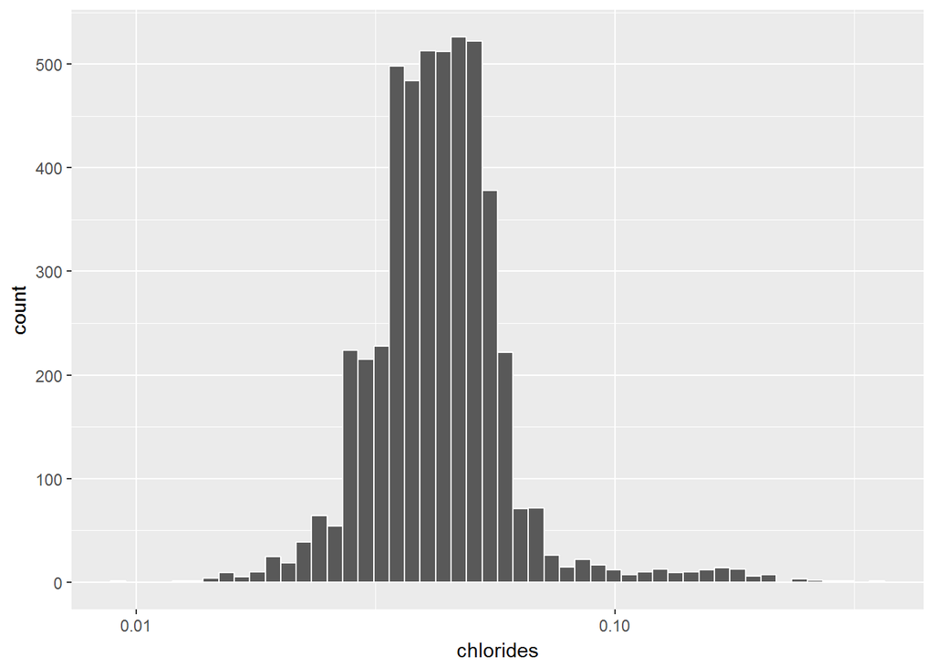

```
##    Min. 1st Qu.  Median    Mean 3rd Qu.    Max.
## 0.00900 0.03600 0.04300 0.04577 0.05000 0.34600
```

x轴数据取对数，转化的图像为正态分布。

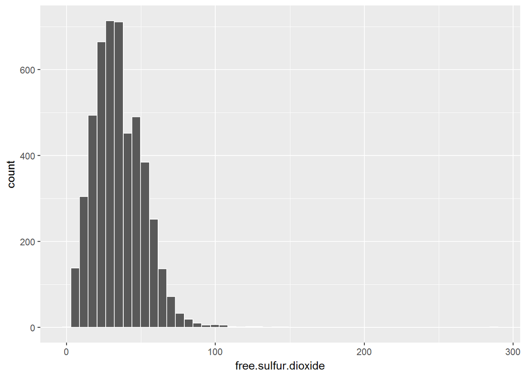

```
##    Min. 1st Qu.  Median    Mean 3rd Qu.    Max.
##    2.00   23.00   34.00   35.31   46.00  289.00
```

自由形式二氧化硫量主要集中在0-100之间，存在异常值。

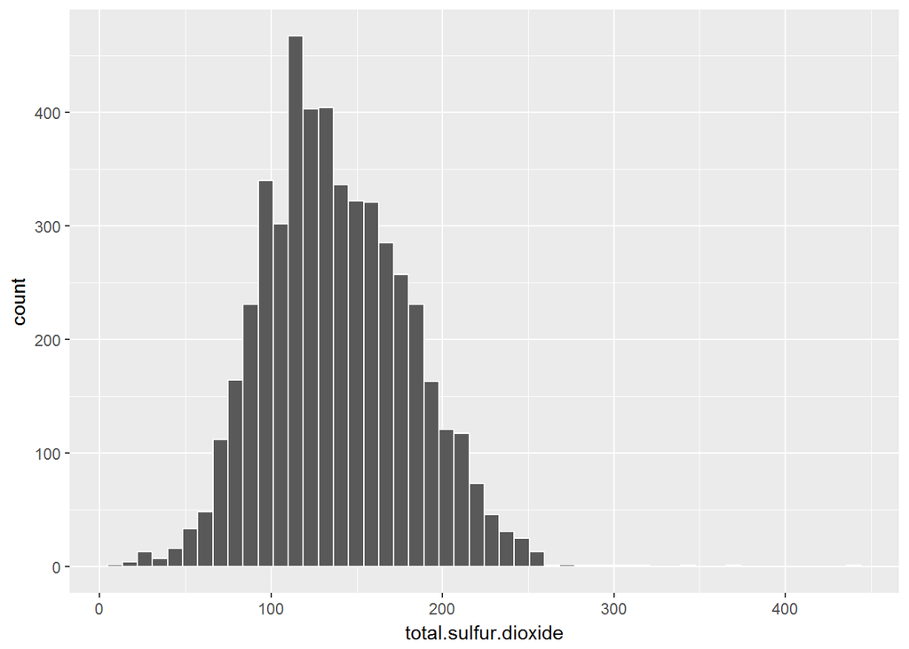

```
##    Min. 1st Qu.  Median    Mean 3rd Qu.    Max.
##     9.0   108.0   134.0   138.4   167.0   440.0
```

白葡萄酒中二氧化硫总量集中在100-200之间，存在异常值。

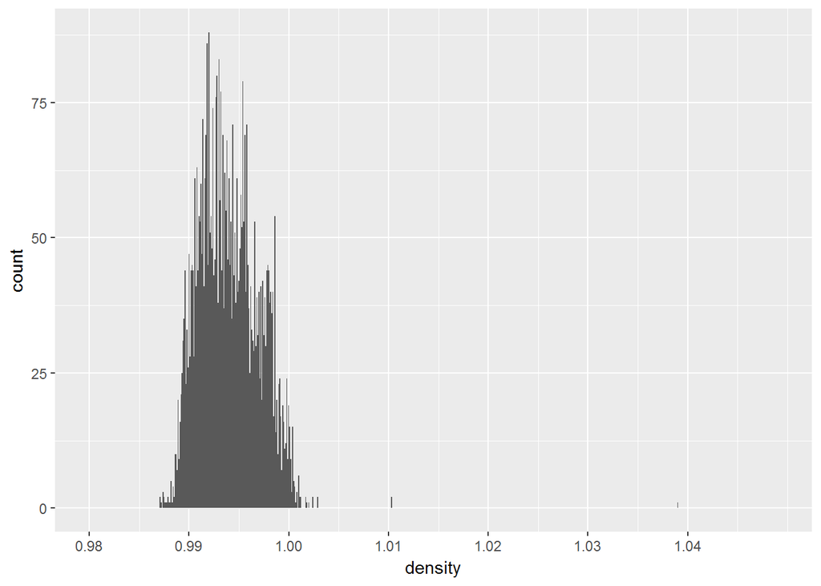

```
##    Min. 1st Qu.  Median    Mean 3rd Qu.    Max.
##  0.9871  0.9917  0.9937  0.9940  0.9961  1.0390
```

白葡萄酒密度变化非常小,集中在0.99-1.0之间，同时存在异常值。

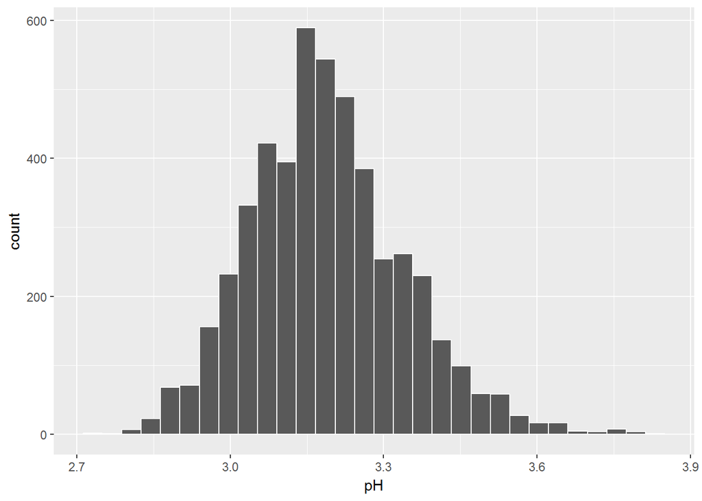

```
##    Min. 1st Qu.  Median    Mean 3rd Qu.    Max.
##   2.720   3.090   3.180   3.188   3.280   3.820
```

酒中pH值大部分在3-3.3之间。

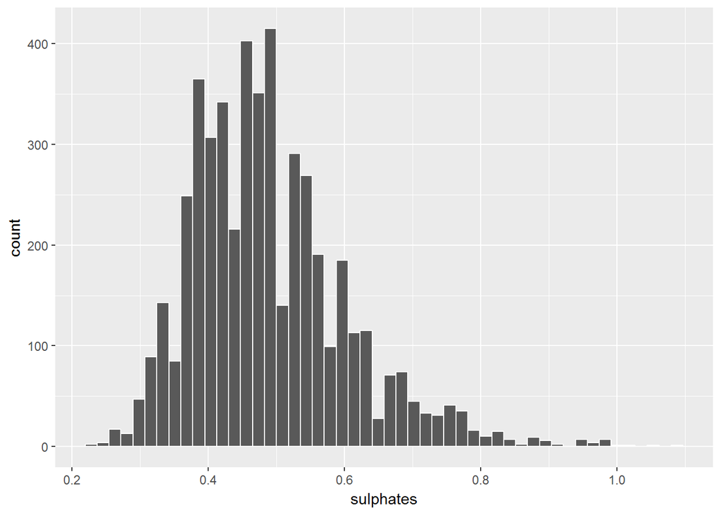

```
##    Min. 1st Qu.  Median    Mean 3rd Qu.    Max.
##  0.2200  0.4100  0.4700  0.4898  0.5500  1.0800
```

酒中硫酸盐主要作用是生存so2,含量在0.4-0.6之间。

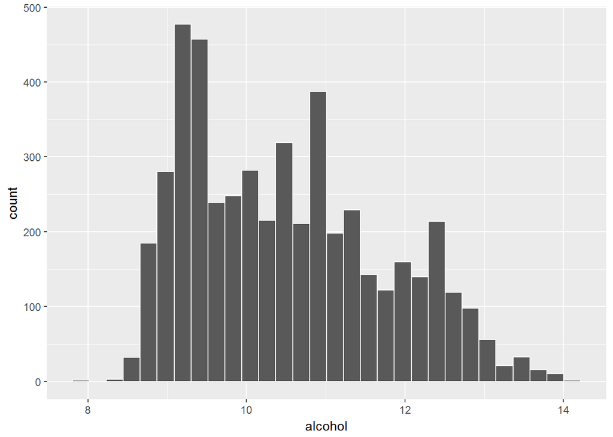

```
##    Min. 1st Qu.  Median    Mean 3rd Qu.    Max.
##    8.00    9.50   10.40   10.51   11.40   14.20
```

酒中酒精含量在8%-14.2%之间。

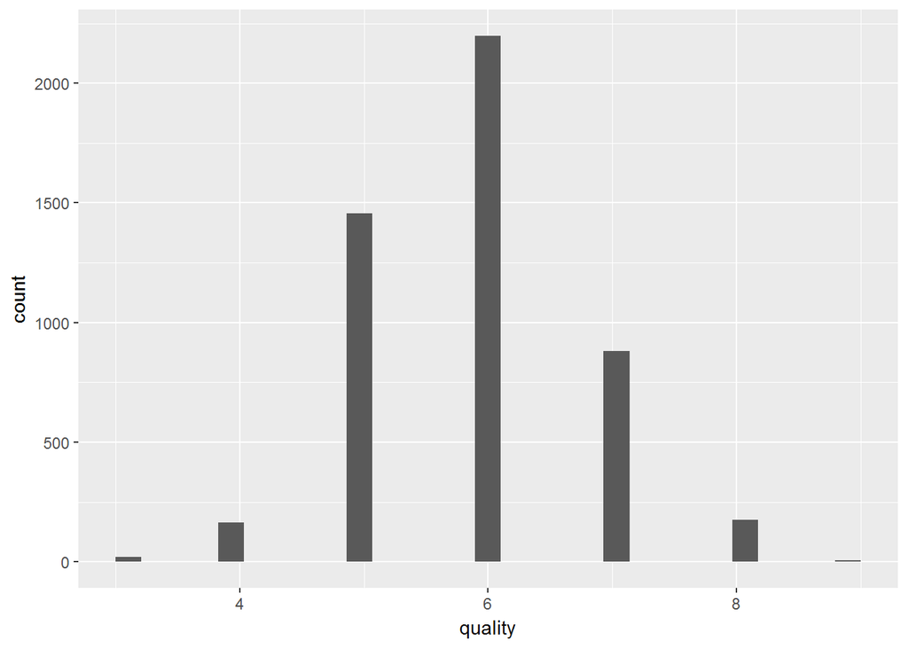

```
##    Min. 1st Qu.  Median    Mean 3rd Qu.    Max.
##   3.000   5.000   6.000   5.878   6.000   9.000
```

```
##
##    3    4    5    6    7    8    9
##   20  163 1457 2198  880  175    5
```

白葡萄酒质量普遍处于中等质量水平，极少数酒能达到高质量，说明白葡萄要做到高质量，难度比较大。

# Univariate Analysis

### What is the structure of your dataset?

1.数据集中有4898种白葡萄酒，每瓶酒有13个数据（x,fixed.acidity,volatile.acidity,citric.acid,residual.sugar,chlorides,free.sulfur.dioxide, total.sulfur.dioxide,density,pH,sulphates,alcohol,quality）。其中变量quality中10分为最好，0分为最差。 2.volatile.acidity,citric.acid,residual.sugar,chlorides,free.sulfur.dioxide,total.sulfur.dioxide,density这7个变量中存在异常值。 3.酒精含量范围是8%-14.2%。 4.白葡萄酒质量最好为9分，最差为3分，其中大部分白葡萄酒是6分。

### What is/are the main feature(s) of interest in your dataset?

酒精（alcohol）和质量（quality）是最感兴趣的特征。

### What other features in the dataset do you think will help support your investigation into your feature(s) of interest?

volatile.acidity,citric.acid,residual.sugar,alcohol,free.sulfur.dioxide等等都可能影响酒的质量。fixed.acidity和density可能影响最大。

### Did you create any new variables from existing variables in the dataset?

创建了总酸度变量total.acidity，下一步将探索总酸度变量是否与质量存在一种联系。

### Of the features you investigated, were there any unusual distributions? Did you perform any operations on the data to tidy, adjust, or change the form of the data? If so, why did you do this?

# Bivariate Plots Section

```
##                      fixed.acidity volatile.acidity  citric.acid
## fixed.acidity           1.00000000      -0.02269729  0.289180698
## volatile.acidity       -0.02269729       1.00000000 -0.149471811
## citric.acid             0.28918070      -0.14947181  1.000000000
## residual.sugar          0.08902070       0.06428606  0.094211624
## chlorides               0.02308564       0.07051157  0.114364448
## free.sulfur.dioxide    -0.04939586      -0.09701194  0.094077221
## total.sulfur.dioxide    0.09106976       0.08926050  0.121130798
## density                 0.26533101       0.02711385  0.149502571
## pH                     -0.42585829      -0.03191537 -0.163748211
## sulphates              -0.01714299      -0.03572815  0.062330940
## alcohol                -0.12088112       0.06771794 -0.075728730
## quality                -0.11366283      -0.19472297 -0.009209091
## total.acidity           0.98717874       0.07157062  0.394143356
##                      residual.sugar   chlorides free.sulfur.dioxide
## fixed.acidity            0.08902070  0.02308564       -0.0493958591
## volatile.acidity         0.06428606  0.07051157       -0.0970119393
## citric.acid              0.09421162  0.11436445        0.0940772210
## residual.sugar           1.00000000  0.08868454        0.2990983537
## chlorides                0.08868454  1.00000000        0.1013923521
## free.sulfur.dioxide      0.29909835  0.10139235        1.0000000000
## total.sulfur.dioxide     0.40143931  0.19891030        0.6155009650
## density                  0.83896645  0.25721132        0.2942104109
## pH                      -0.19413345 -0.09043946       -0.0006177961
## sulphates               -0.02666437  0.01676288        0.0592172458
## alcohol                 -0.45063122 -0.36018871       -0.2501039415
## quality                 -0.09757683 -0.20993441        0.0081580671
## total.acidity            0.10473749  0.04552987       -0.0451333172
##                      total.sulfur.dioxide     density            pH
## fixed.acidity                 0.091069756  0.26533101 -0.4258582910
## volatile.acidity              0.089260504  0.02711385 -0.0319153683
## citric.acid                   0.121130798  0.14950257 -0.1637482114
## residual.sugar                0.401439311  0.83896645 -0.1941334540
## chlorides                     0.198910300  0.25721132 -0.0904394560
## free.sulfur.dioxide           0.615500965  0.29421041 -0.0006177961
## total.sulfur.dioxide          1.000000000  0.52988132  0.0023209718
## density                       0.529881324  1.00000000 -0.0935914935
## pH                            0.002320972 -0.09359149  1.0000000000
## sulphates                     0.134562367  0.07449315  0.1559514973
## alcohol                      -0.448892102 -0.78013762  0.1214320987
## quality                      -0.174737218 -0.30712331  0.0994272457
## total.acidity                 0.113188502  0.27560881 -0.4306513315
##                        sulphates     alcohol      quality total.acidity
## fixed.acidity        -0.01714299 -0.12088112 -0.113662831    0.98717874
## volatile.acidity     -0.03572815  0.06771794 -0.194722969    0.07157062
## citric.acid           0.06233094 -0.07572873 -0.009209091    0.39414336
## residual.sugar       -0.02666437 -0.45063122 -0.097576829    0.10473749
## chlorides             0.01676288 -0.36018871 -0.209934411    0.04552987
## free.sulfur.dioxide   0.05921725 -0.25010394  0.008158067   -0.04513332
## total.sulfur.dioxide  0.13456237 -0.44889210 -0.174737218    0.11318850
## density               0.07449315 -0.78013762 -0.307123313    0.27560881
## pH                    0.15595150  0.12143210  0.099427246   -0.43065133
## sulphates             1.00000000 -0.01743277  0.053677877   -0.01185225
## alcohol              -0.01743277  1.00000000  0.435574715   -0.11751272
## quality               0.05367788  0.43557472  1.000000000   -0.13137721
## total.acidity        -0.01185225 -0.11751272 -0.131377207    1.00000000
```

通过变量之间相关系数计算，alcohol与quality的相关性最大，其次是density、chlorides，但是他们的相关系数低于0.5，因此quality与单个特征相关不明显，而与多个特征会形成比较大的相关性。

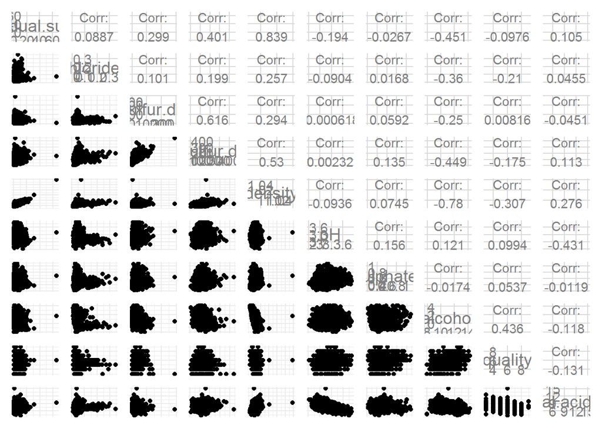

## 这是整个数据集中的部分变量之间的散点图矩阵图，下面我们将详细进行分析：

### （1）探索与质量存在相关性的变量。

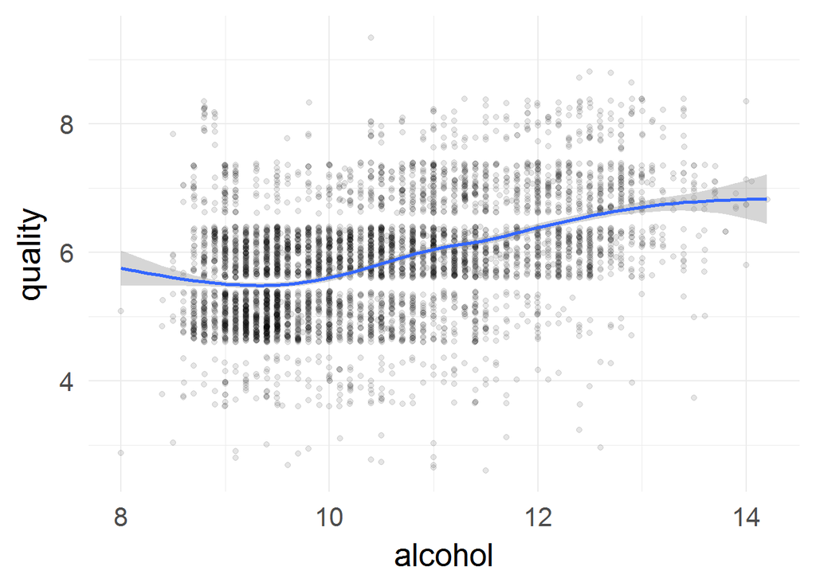

alcohlo和quality有一定的正相关关系，但是不是很明显，。

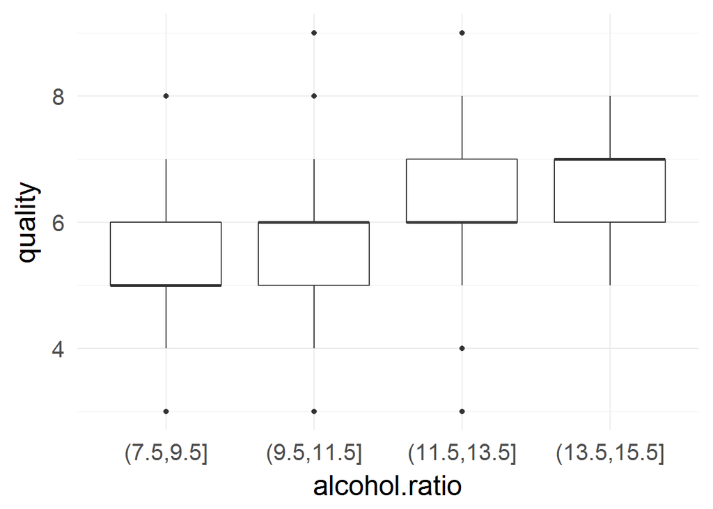

```
## white_wine$alcohol.ratio: (7.5,9.5]
##    Min. 1st Qu.  Median    Mean 3rd Qu.    Max.
##   3.000   5.000   5.000   5.493   6.000   8.000
## --------------------------------------------------------
## white_wine$alcohol.ratio: (9.5,11.5]
##    Min. 1st Qu.  Median    Mean 3rd Qu.    Max.
##   3.000   5.000   6.000   5.836   6.000   9.000
## --------------------------------------------------------
## white_wine$alcohol.ratio: (11.5,13.5]
##    Min. 1st Qu.  Median    Mean 3rd Qu.    Max.
##     3.0     6.0     6.0     6.5     7.0     9.0
## --------------------------------------------------------
## white_wine$alcohol.ratio: (13.5,15.5]
##    Min. 1st Qu.  Median    Mean 3rd Qu.    Max.
##    5.00    6.00    7.00    6.69    7.00    8.00
```

从箱型图中可以看出，酒精含量越高的类别中，中位数也是越高，从侧面也说明了和质量的正相关关系。

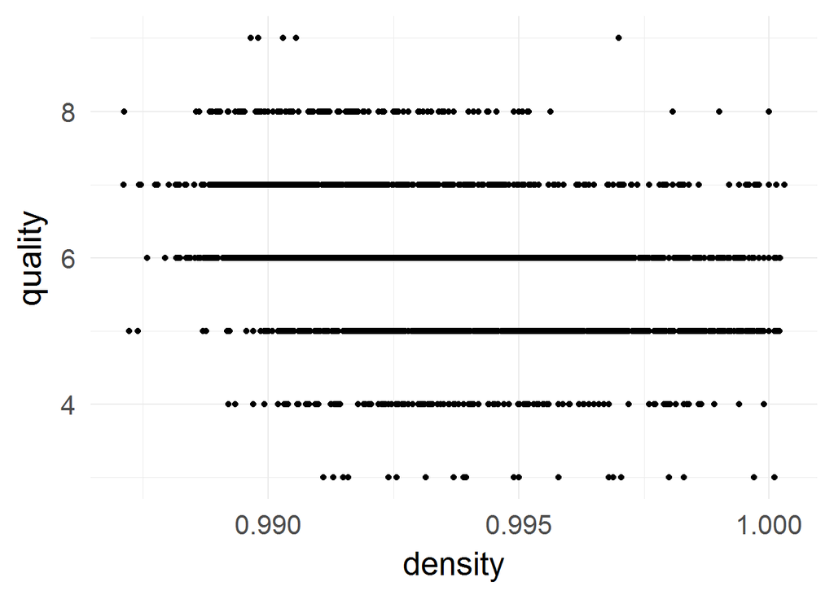

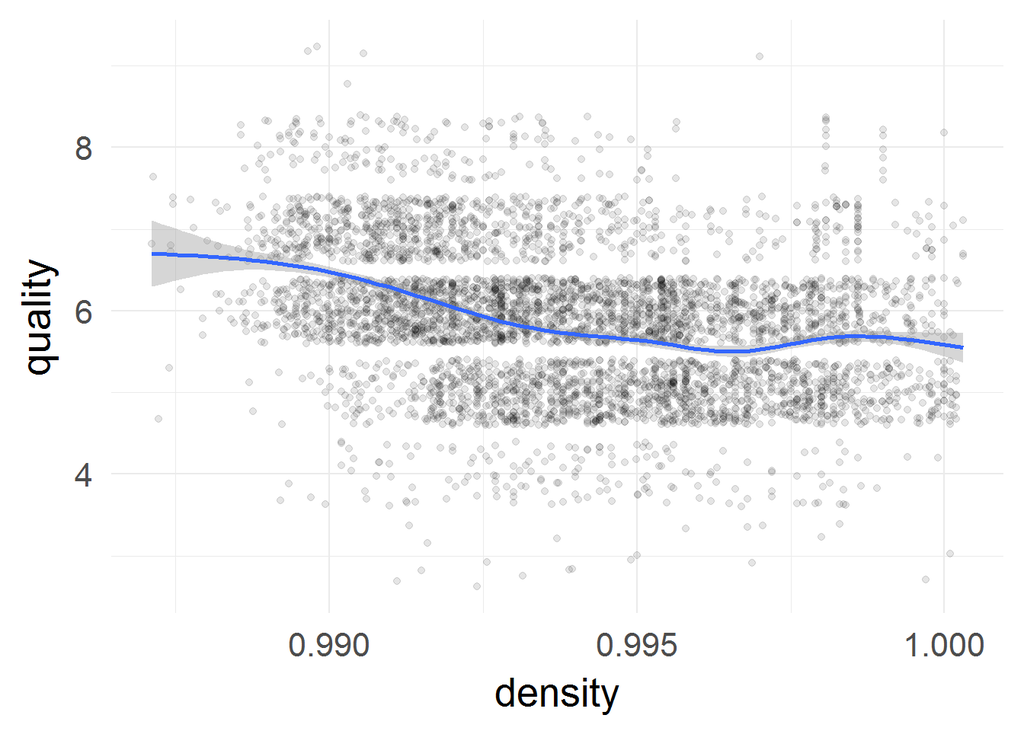

第一张散点图过度绘制，第二张图采取了抖动和降低透明度，增加了平滑器，可以看出density和quality呈现负相关关系。

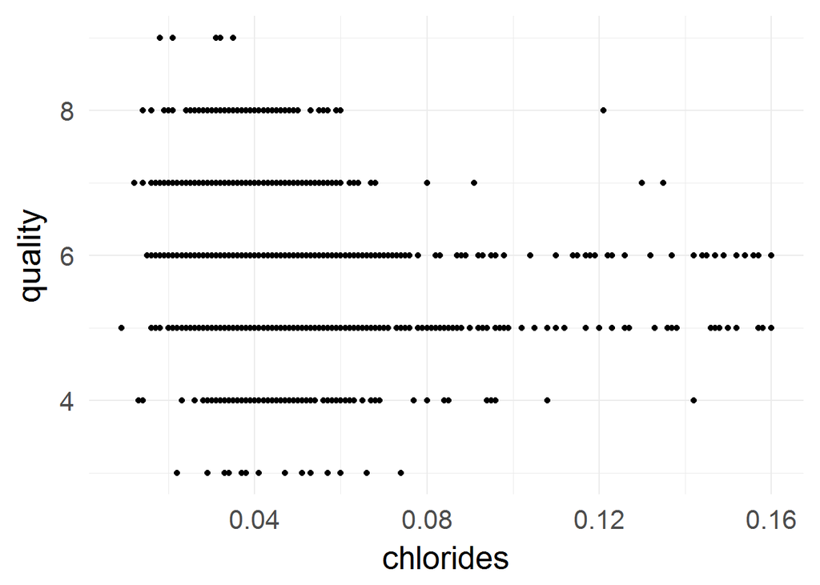

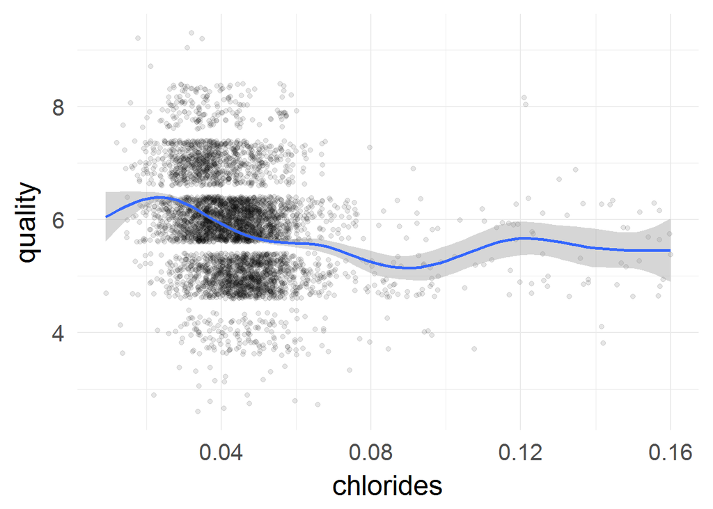

chlorides和quality也是一种负相关关系，效果依然不明显。

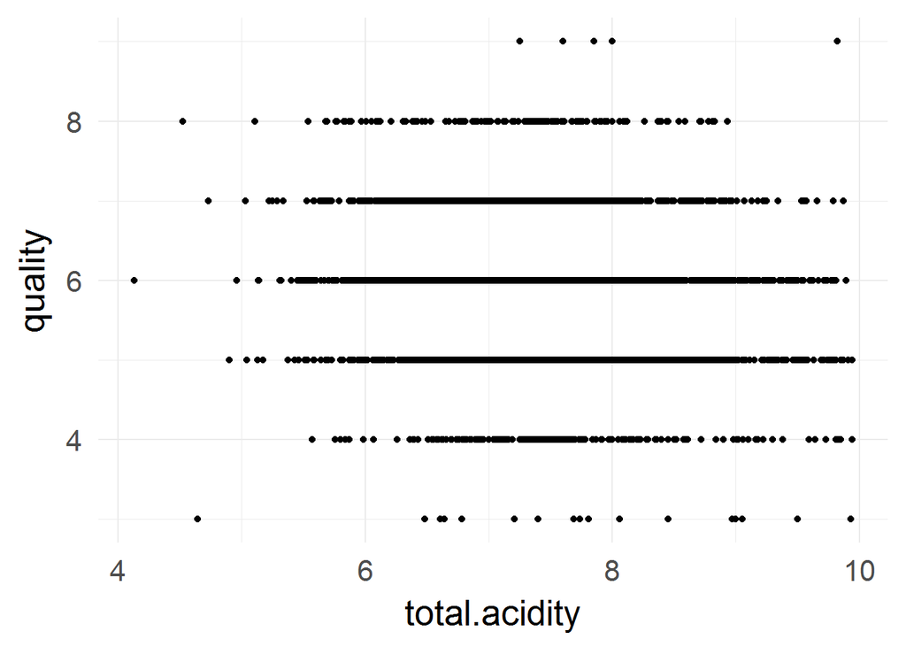

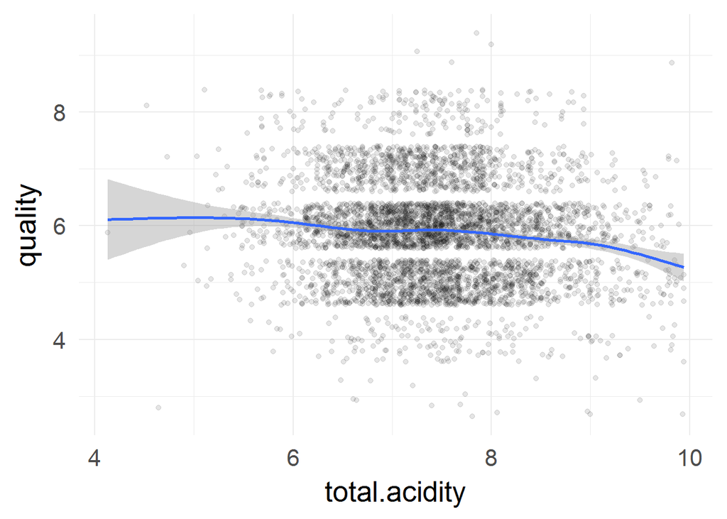

total.acidity和quality有一种微弱的负相关关系。

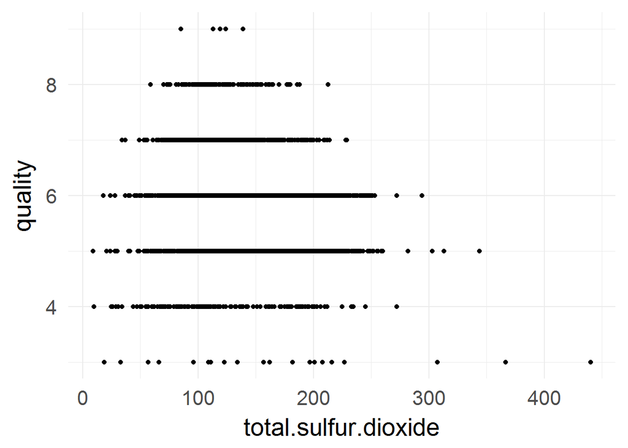

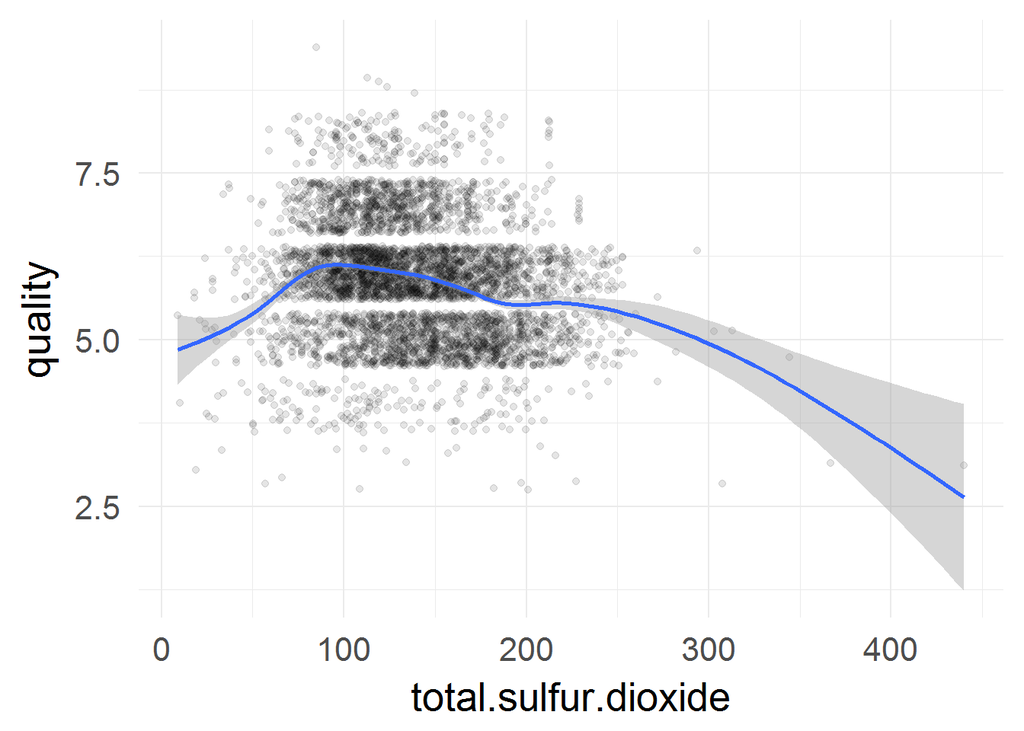

total.sulfur.dioxide和quality也是呈现一种微弱的负相关关系。

### （2）探索其他变量之间的关系。

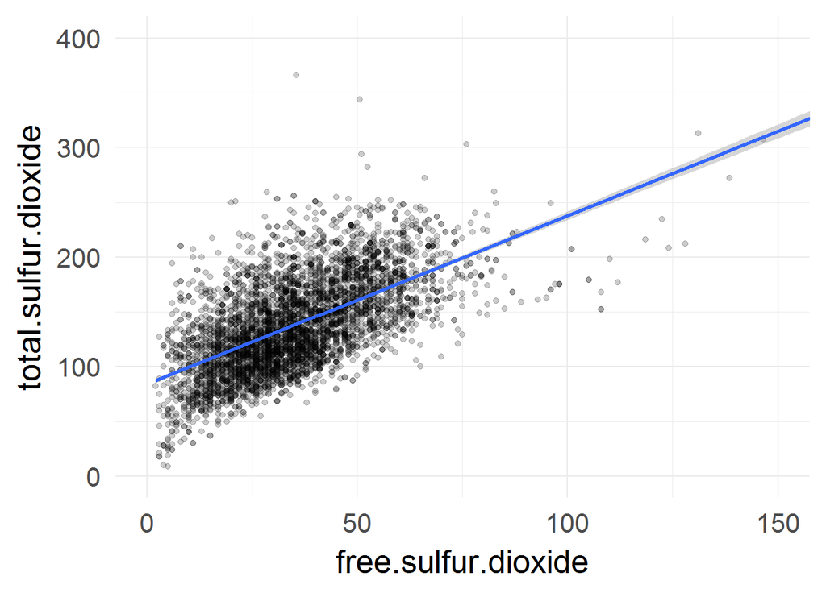

因为total.sulfur.dioxide包含了free.sulfur.dioxide,所以这两个变量为存在正相关关系。

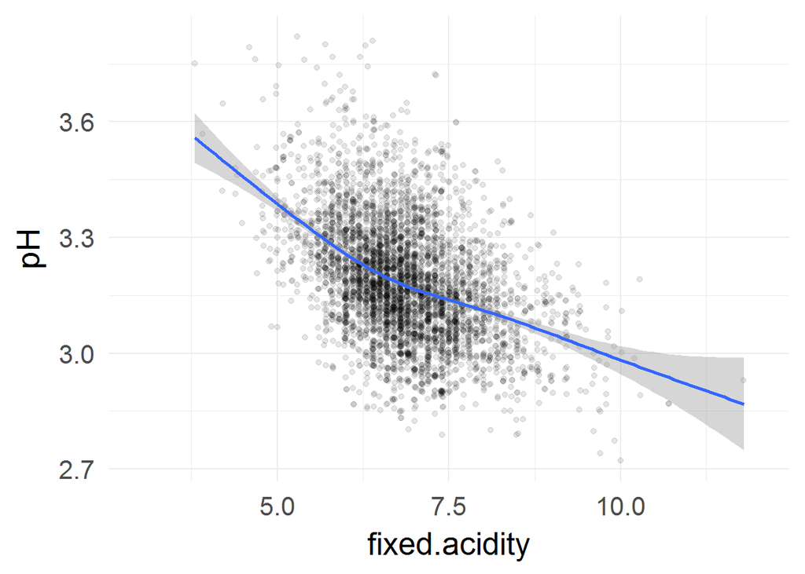

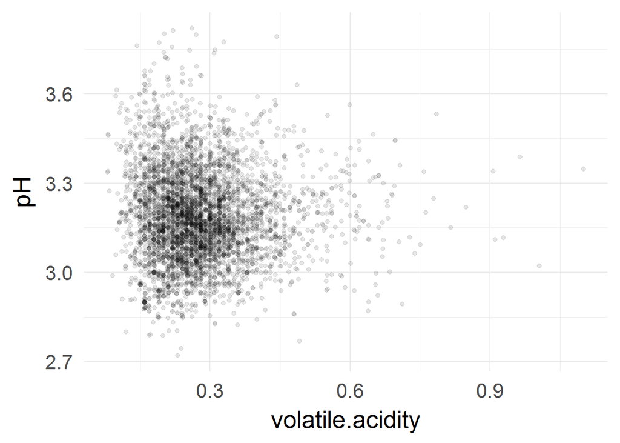

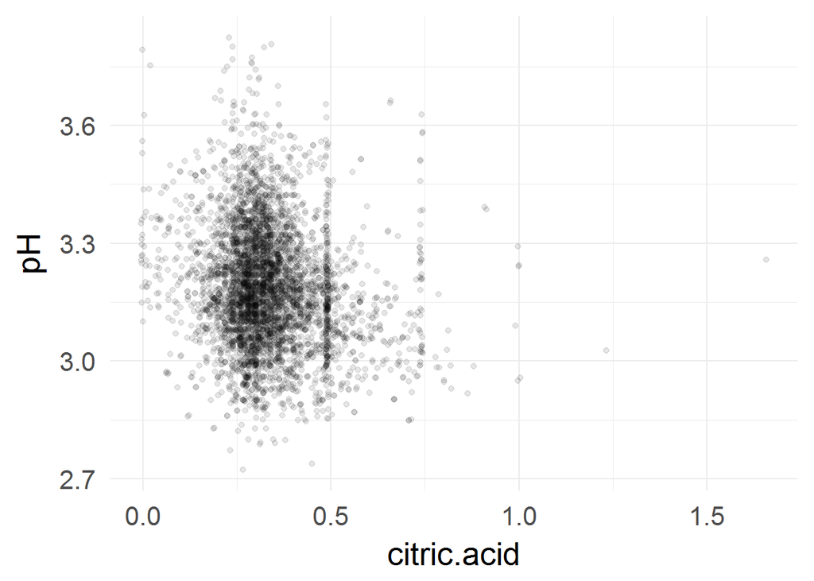

对比上面三张图，可以看出pH值主要与固定酸度（fixed.acidity）有关，当然我们不能排除因为他们含量不在一个级别上。

# Bivariate Analysis

### Talk about some of the relationships you observed in this part of the investigation. How did the feature(s) of interest vary with other features in the dataset?

1.除了alcohol，density、total.sulfur.dioxide、chlorides、total.acidity与quality是负相关关系。

### Did you observe any interesting relationships between the other features (not the main feature(s) of interest)?

1.tolal.sulfur.dioxide与free.sulfur.dioxide呈现正相关关系，说明前者包含了后者。 2.pH值主要受到固定酸度（fixed.acidity）影响。

### What was the strongest relationship you found?

白葡萄酒质量关联最强的是alcohol。